# Classification

Author

Ted Yanez

Published

February 24, 2025

**Abstract:**

This is a technical blog post of **both** an HTML file *and* [.qmd file](https://raw.githubusercontent.com/cd-public/D505/refs/heads/master/hws/src/cond.qmd) hosted on GitHub pages.

# 0. Quarto Type-setting

- This document is rendered with Quarto, and configured to embed an images using the `embed-resources` option in the header.
- If you wish to use a similar header, here’s is the format specification for this document:

```
format:
  html:
    embed-resources: true
```

# 1. Setup

**Step Up Code:**

```r
sh <- suppressPackageStartupMessages
library(tidyverse)
library(caret)
library(naivebayes)
library(tidytext)
sh(library(SnowballC))
sh(library(pROC))
sh(library(glmnet))
sh(library(thematic))
theme_set(theme_dark())
data(stop_words)
wine <- readRDS(gzcon(url("https://cd-public.github.io/D505/dat/pinot.rds")))
names(wine)[names(wine) == 'id'] = 'id'
```

# 2. Logistic Concepts

Why do we call it Logistic Regression even though we are using the technique for classification?

> TODO: It is referred to this because despite being used for classification problems, we still use a logistic function with a linear regression.

# 3. Modeling

We train a logistic regression algorithm to classify a whether a wine comes from Marlborough using:

```r
desc_to_words <- function(df, omits) {
  df %>%
    unnest_tokens(word, description) %>%
    anti_join(stop_words) %>% # get rid of stop words
    filter(!(word %in% omits))
}

words <- desc_to_words(wine, c("wine","pinot","vineyard"))
# The second argument is our custom stopwards, as a vector
head(words)
```

```
  id province price points year     word
1  1   Oregon    65     87 2012  regular
2  1   Oregon    65     87 2012 bottling
3  1   Oregon    65     87 2012     2012
4  1   Oregon    65     87 2012    rough
5  1   Oregon    65     87 2012   tannic
6  1   Oregon    65     87 2012   rustic
```

```r
words_to_stems <- function(df) {
  df %>%
    mutate(word = wordStem(word))
}

stems <- words_to_stems(words)
head(stems)
```

```
  id province price points year    word
1  1   Oregon    65     87 2012 regular
2  1   Oregon    65     87 2012   bottl
3  1   Oregon    65     87 2012    2012
4  1   Oregon    65     87 2012   rough
5  1   Oregon    65     87 2012  tannic
6  1   Oregon    65     87 2012  rustic
```

```r
filter_by_count <- function(df, j) {
  df %>%
    count(id, word) %>%
    group_by(id) %>% mutate(exists = (n>0)) %>% ungroup %>%
    group_by(word) %>%
    mutate(total = sum(n)) %>%
    filter(total > j)
}

pivoter <- function(words, df) {
  words %>%
    pivot_wider(id_cols = id, names_from = word, values_from = exists, values_fill = list(exists=0)) %>%
    right_join(select(df,id,province)) %>%
    drop_na() %>%
    select(-id)
}

wine_words <- function(df, j, stem) {

  words <- desc_to_words(df, c("wine","pinot","vineyard"))

  if (stem) {
    words <- words_to_stems(words)
  }

  words <- filter_by_count(words, j)

  pivoter(words, df)
}


wino <- wine_words(wine, 1000, F)
wino %>%
  head(10) %>%
  select(1:5,province)
```

```
# A tibble: 10 × 6
   drink oak   aromas bodied raspberry province
   <lgl> <lgl> <lgl>  <lgl>  <lgl>     <chr>
 1 TRUE  TRUE  FALSE  FALSE  FALSE     Oregon
 2 FALSE TRUE  TRUE   TRUE   TRUE      California
 3 FALSE FALSE FALSE  FALSE  FALSE     Oregon
 4 FALSE FALSE FALSE  FALSE  FALSE     Oregon
 5 TRUE  FALSE FALSE  FALSE  FALSE     Oregon
 6 FALSE FALSE FALSE  FALSE  TRUE      California
 7 FALSE FALSE FALSE  FALSE  TRUE      California
 8 FALSE TRUE  FALSE  FALSE  TRUE      California
 9 FALSE FALSE FALSE  FALSE  FALSE     Oregon
10 FALSE FALSE TRUE   FALSE  FALSE     Oregon
```

```r
winor <- wine_words(wine, 1000, T) %>%
           mutate(
             marlborough = as.factor(province == "Marlborough")) %>%
           select(-province)
set.seed(505)
wine_index <- createDataPartition(wino$province, p = 0.80, list = FALSE)
train <- wino[ wine_index, ]
test <- wino[-wine_index, ]
table(train$province)
```

```
         Burgundy        California Casablanca_Valley       Marlborough
              952              3147               104               180
         New_York            Oregon
              105              2156
```

```r
control = trainControl(method = "cv", number = 5)
get_fit <- function(df) {
  train(province ~ .,
        data = df,
        trControl = control,
        method = "multinom",
        maxit = 5) # speed it up - default 100
}
fit <- get_fit(train)
get_odds <- function(fit) {
  as.data.frame(t(exp(coef(fit$finalModel))))   %>%
  rownames_to_column(var = "name") %>%
  pivot_longer(-name, names_to = "class", values_to = "odds") %>%
  arrange(desc(odds)) %>%
  head()
}
get_odds(fit)
```

```
# A tibble: 6 × 3
  name        class              odds
  <chr>       <chr>             <dbl>
1 bodiedTRUE  California         4.86
2 (Intercept) Oregon             3.88
3 noseTRUE    California         2.82
4 oakTRUE     California         2.70
5 aromasTRUE  California         2.67
6 aromasTRUE  Casablanca_Valley  2.31
```

```r
get_matrix <- function(fit, df) {
  pred <- factor(predict(fit, newdata = df))
  confusionMatrix(pred,factor(df$province))
}
get_matrix(fit,test)
```

```
Confusion Matrix and Statistics

                   Reference
Prediction          Burgundy California Casablanca_Valley Marlborough New_York
  Burgundy               180         39                 1           5        6
  California              30        594                10          19       12
  Casablanca_Valley        0          2                13           0        1
  Marlborough              0          0                 0           0        0
  New_York                 0          0                 0           0        0
  Oregon                  28        151                 2          20        7
                   Reference
Prediction          Oregon
  Burgundy              38
  California            88
  Casablanca_Valley      1
  Marlborough            0
  New_York               0
  Oregon               411

Overall Statistics

               Accuracy : 0.7226
                 95% CI : (0.7003, 0.744)
    No Information Rate : 0.4741
    P-Value [Acc > NIR] : < 2.2e-16

                  Kappa : 0.5666

 Mcnemar's Test P-Value : NA

Statistics by Class:

                     Class: Burgundy Class: California Class: Casablanca_Valley
Sensitivity                   0.7563            0.7557                 0.500000
Specificity                   0.9373            0.8177                 0.997549
Pos Pred Value                0.6691            0.7888                 0.764706
Neg Pred Value                0.9582            0.7878                 0.992078
Prevalence                    0.1435            0.4741                 0.015682
Detection Rate                0.1086            0.3583                 0.007841
Detection Prevalence          0.1622            0.4542                 0.010253
Balanced Accuracy             0.8468            0.7867                 0.748775
                     Class: Marlborough Class: New_York Class: Oregon
Sensitivity                     0.00000         0.00000        0.7639
Specificity                     1.00000         1.00000        0.8143
Pos Pred Value                      NaN             NaN        0.6640
Neg Pred Value                  0.97346         0.98432        0.8778
Prevalence                      0.02654         0.01568        0.3245
Detection Rate                  0.00000         0.00000        0.2479
Detection Prevalence            0.00000         0.00000        0.3733
Balanced Accuracy               0.50000         0.50000        0.7891
```

```r
winor <- wine_words(wine, 1000, T) %>%
           mutate(Marlborough = as.factor(province == "Marlborough")) %>%
           select(-province)
wine_index <- createDataPartition(winor$Marlborough, p = 0.80, list = FALSE)
train <- winor[wine_index, ]
test <- winor[-wine_index, ]

fit <- train(Marlborough ~ .,
             data = train,
             trControl = control,
             method = "glm",
             family = "binomial")

print(fit)
```

```
Generalized Linear Model

6688 samples
  29 predictor
   2 classes: 'FALSE', 'TRUE'

No pre-processing
Resampling: Cross-Validated (5 fold)
Summary of sample sizes: 5350, 5350, 5351, 5350, 5351
Resampling results:

  Accuracy   Kappa
  0.9771237  0.3560105
```

> TODO: Based on the model labelled fit, our kappa is 0.356, which isn’t great, but it’s not bad.

# 4. Binary vs Other Classification

What is the difference between determining some form of classification through logistic regression versus methods like $K$-NN and Naive Bayes which performed classifications.

> TODO: In short, logistic regression models are used when it’s important to interpret coefficients (the rate at which a predictor affects our model), $K$-NN models are used when you just need a simple model that’s easy to implement (though it can take a while for your computer to calculate), and Naive Bayes is best used when you have a large dataset with categorical features. Logistic regression calculates the probability of a class based on linear features. $K$-NN classifies data based on the class of other data points nearest in training data (hence, “Nearest Neighbors”). Naive Bayes calculates probabilities based on Bayes’ theorem and makes predictions based on the assumption of feature independence.

# 5. ROC Curves

We can display an ROC for the model to explain your model’s quality.

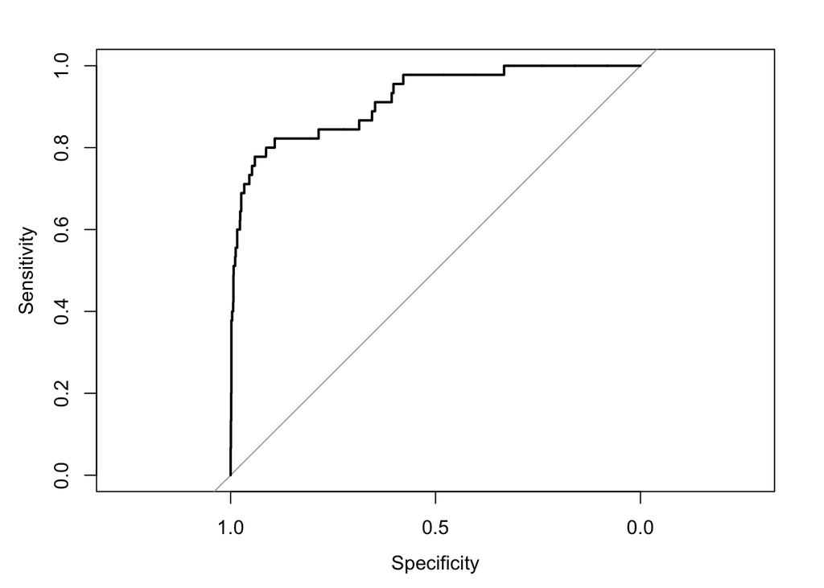

```r
prob <- predict(fit, newdata = test, type = "prob")[,2]
myRoc <- roc(test$Marlborough, prob)
plot(myRoc)
```

```r
auc(myRoc)
```

```
Area under the curve: 0.9178
```

> TODO: Using the area under the curve, we can see how accurate this model is. The scale is between 0 and 1, 1 signifying 100 percent. The closer to 1 we get, the better the model.